# Final Project Report

Alvin Chen

## Research Question

Specific Research Question: What is the correlation between wealth group of countries (high, upper middle, lower middle, low) and their effects on climate change? Which one contributes the most?

Climate change is a problem that impacts our daily lives and it has become a main global issue. Studying the relationships between different countries and their contributions to climate change can be crucial in devising plans to slow climate change on our planet. This topic sparks my interest as it not only effects me, but it also can be devastating for the future of our planet. In studying and generating research, helpful insight can be provided to help spread awareness and provide understanding in which group of countries are contributing the most to this global issue.

The data used for this report can be found/downloaded at: https://data.worldbank.org/indicator/EN.ATM.CO2E.PC

## Data Processing

```r
# import statements
library(tidyverse)
library(readr)
```

#### Data Intake

```r
# path of CO2 emissions data set
co2em_file <- 'API_EN.ATM.CO2E.PC_DS2_en_csv_v2_10576797.csv'

# read csv file
co2em <- read_csv(co2em_file)
# examine
glimpse(co2em)
```

```
Rows: 264
Columns: 64
$ `Country Name`   <chr> "Aruba", "Afghanistan", "Angola", "Albania", "Andorra", "Arab World", "United Ar…
$ `Country Code`   <chr> "ABW", "AFG", "AGO", "ALB", "AND", "ARB", "ARE", "ARG", "ARM", "ASM", "ATG", "AU…
$ `Indicator Name` <chr> "CO2 emissions (metric tons per capita)", "CO2 emissions (metric tons per capita…
$ `Indicator Code` <chr> "EN.ATM.CO2E.PC", "EN.ATM.CO2E.PC", "EN.ATM.CO2E.PC", "EN.ATM.CO2E.PC", "EN.ATM.…
$ `1960`           <dbl> NA, 0.046059897, 0.097471604, 1.258194928, NA, 0.643689011, 0.118757692, 2.36747…
$ `1961`           <dbl> NA, 0.05360430, 0.07903809, 1.37418605, NA, 0.68515088, 0.10883674, 2.44261590, …
$ `1962`           <dbl> NA, 0.07376479, 0.20128908, 1.43995596, NA, 0.76085451, 0.16301835, 2.52239210, …
$ `1963`           <dbl> NA, 0.07423268, 0.19253473, 1.18168114, NA, 0.87494119, 0.17522259, 2.31635633, …
$ `1964`           <dbl> NA, 0.08629245, 0.20100336, 1.11174196, NA, 0.99909766, 0.13235496, 2.53837930, …
$ `1965`           <dbl> NA, 0.10146740, 0.19152841, 1.16609904, NA, 1.16570539, 0.14632686, 2.64171434, …
$ `1966`           <dbl> NA, 0.10763696, 0.24641279, 1.33305546, NA, 1.27265067, 0.15995040, 2.79265380, …
$ `1967`           <dbl> NA, 0.12373429, 0.15491158, 1.36374630, NA, 1.33140440, 5.38368481, 2.85816230, …
$ `1968`           <dbl> NA, 0.11549774, 0.25631600, 1.51955128, NA, 1.54494253, 6.78577355, 2.96985458, …
```

[output cut: 51 more lines]

##### Written explanation:

This data was collected by Climate Watch in 2020. The purpose of this data is to display the amount of CO2 emissions by country spread across many years. This data was taken in order to form a correlation between countries and CO2 output.

##### Examine Data Source:

Looking at thee co2em data set, it is clear to see that there are some missing variables for some countries on some years in the table. As a result this data some countries will be removed and ignored in data consideration. In order to contribute to the guiding questions some key variables that stand out are the countries name, and the the years with the emission amount data. To answer my question, I will need to clean my data, and remove some outlier variables that wont contribute to the study.

```r
# path of income groups data set
income_file <- 'Metadata_Country_API_EN.ATM.CO2E.PC_DS2_en_csv_v2_5551837.csv'

# read csv file
income <- read_csv(income_file)
# examine
glimpse(income)
```

```
Rows: 265
Columns: 6
$ `Country Code` <chr> "ABW", "AFE", "AFG", "AFW", "AGO", "ALB", "AND", "ARB", "ARE", "ARG", "ARM", "ASM"…
$ Region         <chr> "Latin America & Caribbean", NA, "South Asia", NA, "Sub-Saharan Africa", "Europe &…
$ IncomeGroup    <chr> "High income", NA, "Low income", NA, "Lower middle income", "Upper middle income",…
$ SpecialNotes   <chr> NA, "26 countries, stretching from the Red Sea in the North to the Cape of Good Ho…
$ TableName      <chr> "Aruba", "Africa Eastern and Southern", "Afghanistan", "Africa Western and Central…
$ ...6           <lgl> NA, NA, NA, NA, NA, NA, NA, NA, NA, NA, NA, NA, NA, NA, NA, NA, NA, NA, NA, NA, NA…
```

#### Written explanation

This data was sourced by The World Bank in 2022. The purpose of this data is to assign whether a country is high to low income class based on their respective dollar values. This data was taken in order to form a correlation between countries and income status.

#### Examine Data Source:

Looking at the income data set, it is clear to see that there are also some missing variables and empty columns. This will lead to the need for data cleaning to remove countries with missing data and removing variables that aren’t needed for the study such as special notes and region. Variable that will likely be helpful are country names and also the class or income group. To work towards my research question it is planned to clean and merge the data sets as well as the possible creation of new variables to display groups of countries in a descending bar graph.

## Data Wrangling

```r
# clean the co2em and income data set
# remove columns with no data
co2em_clean <-
  co2em[, 1:(ncol(co2em) - 5)]

# remove columns with no data
income_clean <-
  income[, c(3, 5)]

# designate data both data sets to remove incomplete cases
datasets_to_clean <- list(co2em_clean, income_clean)

# for loop to remove the the incomplete cases from the data sets
for (dataset in datasets_to_clean) {
    # remove incomplete cases
  dataset <- dataset[complete.cases(dataset), ]
    # assign clean data back to the original datasets
  assign(deparse(substitute(dataset)), dataset)
}

# remove unwanted columns in CO2 data set
co2_cleaned <- co2_cleaned[, -c(2:4)]

# rename column in income data set
names(income_cleaned)[2] <- "Country Name"

# merge two datasets into one by country name
co2_income <- merge(income_cleaned, co2_cleaned, by = "Country Name")

# remove space in country name variable
names(co2_income)[1] <- "CountryName"

# covert to long format to graph dates
co2_income_long <- tidyr::gather(co2_income, year, value, -CountryName, -IncomeGroup)

# change names of year and value
names(co2_income_long)[3] <- "Year"
names(co2_income_long)[4] <- "CO2(metric tons per capita)"

# calculate the sum of CO2 production on all years for each country
sum_co2_all_year <- aggregate(`CO2(metric tons per capita)` ~ CountryName + IncomeGroup, co2_income_long, sum)

# calculate the avg of the sums for each country within their income groups
avg_co2_all_year <- aggregate(`CO2(metric tons per capita)` ~ IncomeGroup, sum_co2_all_year, mean, na.rm = TRUE)

# merged the calculated averages with the original data set
co2_income_merged <- co2_income_long %>%
  left_join(avg_co2_all_year, by = "IncomeGroup") %>%
  mutate(AvgCO2 = `CO2(metric tons per capita).y`)

# remove the extra added row that is not needed
co2_income_merged <- co2_income_merged %>%
  select(-5)

# rename the modified row name back to original to have a complete clean dated for graphing
names(co2_income_merged)[4] <- "CO2(metric tons per capita)"
```

## Data Visualization

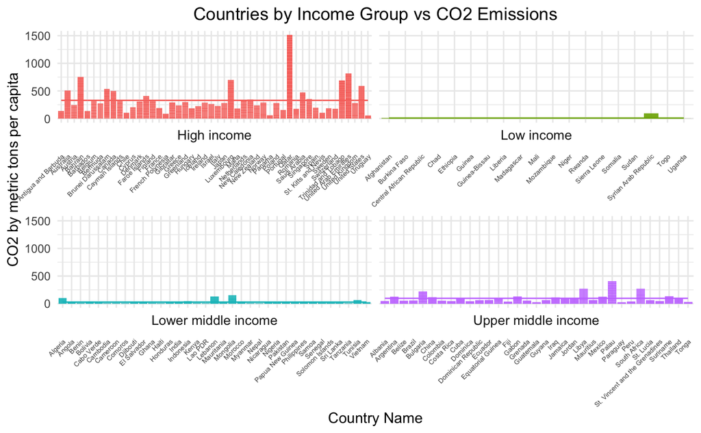

```r
# graph the data set
ggplot(co2_income_merged) +
  # layer a bar graph and a line graph
  geom_bar(aes(x = CountryName, y = `CO2(metric tons per capita)`, fill = IncomeGroup), stat = "identity") +
  geom_line(aes(x = CountryName, y = `AvgCO2`, color = IncomeGroup, group = IncomeGroup), linetype = "solid", size = .5, show.legend = FALSE) +
  # label the axis in the graph
  labs(
    x = "Country Name",
    y = "CO2 by metric tons per capita",
    title = "Countries by Income Group vs CO2 Emissions"
  ) +
  theme_minimal() +
  # correct the size of texts and other aesthetics of graph
  theme(
    axis.text.x = element_text(angle = 45, hjust = 1, vjust = 1, size = 5),
    strip.text = element_text(size = 10),
    plot.title = element_text(hjust = 0.5)
  ) +
  # divide by income groups
  facet_wrap(~ IncomeGroup, ncol = 2, strip.position = "bottom", scales = "free_x") +
  guides(fill = FALSE)
```

Explanation:

The graph above shows detailed information regarding countries and their CO2 production combined from the years 1960-2015. It displays helpful qualities such as subgroups of countries divided by their income class and also layered with a general trend line on how much C02 production is being produced by each country. In analyzing the graph it is noticeable that the high income group of countries product the most CO2 emission over this course of time. This graph will prove helpful in answering all parts of my research question.